# Examinations for May – September 2022 Semester

```python
#Course Code : CS 505/501
#Programme(s) : Master of Science in Comp (Comp. Security)
#Year of Study :  One
#Course Name : Advanced Programming/Advanced Programming Principles
#School of Computing and Engineering
```

```python
#Name: Mwanje Musa
#Reg No: MAY22/MSC/1615U
#Programme: MSc. COMP (CS)
```

# a) Use the codes in the figure to generate the map of Uganda (4 marks)

```python
import numpy as np
import pandas as pd
```

```python
pip install folium
```

```python
!conda install -c conda-forge folium=0.5.0 --yes
import folium
print('Folium installed and imported!')
```

```
Solving environment: done

# All requested packages already installed.

Folium installed and imported!
```

```python
uganda_latitude = 1.3733
uganda_longitude = 32.2903
uganda_map = folium.Map(location=[uganda_latitude, uganda_longitude],zoom_start=7)
uganda_map
```

Make this Notebook Trusted to load map: File -> Trust Notebook

[interactive chart not shown]

# b) Write other codes that create marker as seen on Ontario City in Canada for the following cities in Uganda:

# i. Kampala (4 marks)

```python
kampala_map = folium.Map(location=[0.3130293, 32.5991254],zoom_start=12)
kampala_map
```

Make this Notebook Trusted to load map: File -> Trust Notebook

[interactive chart not shown]

# ii. Jinja (4 marks)

```python
jinja_map = folium.Map(location=[0.416665, 33.1999992],zoom_start=12)
jinja_map
```

Make this Notebook Trusted to load map: File -> Trust Notebook

[interactive chart not shown]

# iii. Gulu (4 marks)

```python
gulu_map = folium.Map(location=[2.774663568, 32.2999988],zoom_start=12)
gulu_map
```

Make this Notebook Trusted to load map: File -> Trust Notebook

[interactive chart not shown]

# iv. Mbarara (4 marks)

```python
mbarara_map = folium.Map(location=[-0.607997568, 30.65499738],zoom_start=12)
mbarara_map
```

Make this Notebook Trusted to load map: File -> Trust Notebook

[interactive chart not shown]

As a master of Science student, with the knowledge of 3 D figures, write python codes in Jupyter notebook environment that can transform the photograph obtained from URL: https://pbs.twimg.com/media/FRFW7d_XwAAoG8a?format=jpg&name=medium to be seen as figures in Question Four and Question Five with all the dimensions labeled respectively.

# Question Four

```python
import numpy as np
import cv2
import matplotlib.pyplot as plt
```

```python
# reads image 'opencv-logo.png'
img = cv2.imread('FRFW7d_XwAAoG8a.jpeg', cv2.COLOR_BGR2RGB) # the source of the image is
```

```python
type(img)
```

```
numpy.ndarray
```

```python
img.shape
```

```
(1033, 1080, 3)
```

```python
img.max()
```

```
255
```

```python
img.min()
```

```
0
```

```python
new_image=cv2.cvtColor(img, cv2.COLOR_BGR2RGB)
```

[figure not shown]

```python
plt.figure(figsize=(10,10))
plt.imshow(new_image)
plt.show()
```

# Question Five

```python
cv2.imwrite('FRFW7d_XwAAoG8a.png',new_image)
```

```
True
```

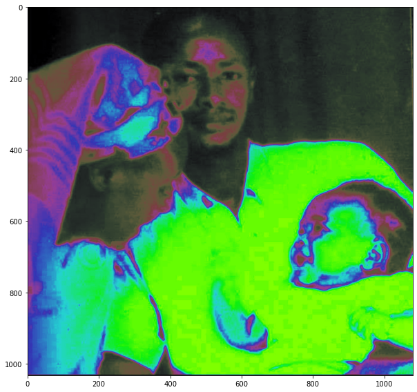

```python
img_BGR = cv2.cvtColor(new_image, cv2.COLOR_HSV2BGR)

plt.figure(figsize=(10,10))
plt.imshow(img_BGR, cmap='gray', vmin = 0, vmax = 255)
plt.show()
```

# Section A (40 Marks)

```python
import pandas as pd
import numpy as np
```

a) The variable release_year_dict is a Python Dictionary, what is the result of applying the following method: release_year_dict.keys() ? (3 marks)

```python
#Assuming i pass the following variables to the method
release_year_dict = {'a':1, 'b':2}
print ('Result of the method release_year_dict.keys() is :',release_year_dict.keys(), 'this is simple because it retrieves the keys of the dictionary')
```

```
Result of the method release_year_dict.keys() is : dict_keys(['a', 'b']) this is simple because it retrieves the keys of the dictionary
```

b) In Python 3, what is the type of the variable x after the following: x=1/1 (3 marks)

```python
print('The value of X: ', (1/1),'and Variable type is float')
```

```
The value of X:  1.0 and Variable type is float
```

c) Consider the dataframe df how would you access the element in the 1st row 3rd column? (3 marks)

```python
df = pd.read_csv('cell_samples.csv')
df.head(1)
```

|  | ID | Clump | UnifSize | UnifShape | MargAdh | SingEpiSize | BareNuc | BlandChrom | NormNucl | Mit | Class |
| --- | --- | --- | --- | --- | --- | --- | --- | --- | --- | --- | --- |
| 0 | 1000025 | 5 | 1 | 1 | 1 | 2 | 1 | 3 | 1 | 1 | 2 |

```python
df.loc[0].at["UnifSize"]
```

```
1
```

d) In the class, you learned you can also obtain a series from a dataframe df, write the correct way to assign the column with the header Length to a pandas series to the variable x. (3 marks)

```python
print ('This is how we assign the column with the header Length in pandas: ',"x=df['Length']")
```

```
This is how we assign the column with the header Length in pandas:  x=df['Length']
```

e) What is the result of applying the following method df.head(), to the dataframe df (3 marks)

```python
df.head()
#The head() function is used to get the first n rows.
#This function returns the first n rows for the object based on position. as you can see in the figure below
```

|  | ID | Clump | UnifSize | UnifShape | MargAdh | SingEpiSize | BareNuc | BlandChrom | NormNucl | Mit | Class |
| --- | --- | --- | --- | --- | --- | --- | --- | --- | --- | --- | --- |
| 0 | 1000025 | 5 | 1 | 1 | 1 | 2 | 1 | 3 | 1 | 1 | 2 |
| 1 | 1002945 | 5 | 4 | 4 | 5 | 7 | 10 | 3 | 2 | 1 | 2 |
| 2 | 1015425 | 3 | 1 | 1 | 1 | 2 | 2 | 3 | 1 | 1 | 2 |
| 3 | 1016277 | 6 | 8 | 8 | 1 | 3 | 4 | 3 | 7 | 1 | 2 |
| 4 | 1017023 | 4 | 1 | 1 | 3 | 2 | 1 | 3 | 1 | 1 | 2 |

f) How do you cast the list A to the set a? (3 marks)

```python
# initializing set
ini_set = {10, 20, 30, 40, 50}

# printing initialized set
print ("initial string", ini_set)
print (type(ini_set))

# Converting set to dictionary
res = dict.fromkeys(ini_set, 0)

# printing final result and its type
print ("final list", res)
print (type(res))
```

```
initial string {50, 20, 40, 10, 30}
<class 'set'>
final list {50: 0, 20: 0, 40: 0, 10: 0, 30: 0}
<class 'dict'>
```

g) What is the result of the following: 'C' in {'A','B'}? (3 marks)

```python
'C' in {'A','B'}
```

```
False
```

h) Consider the Set: V={'1','2'}, what is the result of V.add('3')? (3 marks)

```python
V={'1','2'}
print ("Results of V.add('3') is :", V.add('3'))
```

```
Results of V.add('3') is : None
```

i) Consider the Set: U=['1','2'], write a code for adding 3 in set U? (3 marks)

```python
#my list here
U = ['1', '2']

#function for adding
U.append('3')

print('My New List is :',U, 'and we use the append method to achive that')
```

```
My New List is : ['1', '2', '3'] and we use the append method to achive that
```

j) What is the result of the following: str(1)+str(6)? (3 marks)

```python
print ('Result of str(1)+str(6)? is : ',str(1)+str(6))
```

```
Result of str(1)+str(6)? is :  16
```

k) Consider the variable B ={“WHO Region”, “Geographical location”, “longitude and latitude” }. Write python code that can change WHO Region to “Region”, Geographical location to “Location”, longitude and latitude to “Location”. (4 marks)

```python
# this is my sample data frame
df = pd.DataFrame({'WHO Region': ["Central", "Eastern", "Western"],

                   'Geographical location': ["Kampala", "Jinja", "Mbarara"],

                   'longitude and latitude': [2.774663568, 32.2999988, 1.3733]})

# print data frame
display(df)

dict = {'WHO Region': 'Region',
        'Geographical location': 'Location',
        'longitude and latitude': 'Location'}

# call rename () method
df.rename(columns=dict,
          inplace=True)

# print Output Data frame after rename columns
display(df)
```

|  | WHO Region | Geographical location | longitude and latitude |
| --- | --- | --- | --- |
| 0 | Central | Kampala | 2.774664 |
| 1 | Eastern | Jinja | 32.299999 |
| 2 | Western | Mbarara | 1.373300 |

|  | Region | Location | Location |
| --- | --- | --- | --- |
| 0 | Central | Kampala | 2.774664 |
| 1 | Eastern | Jinja | 32.299999 |
| 2 | Western | Mbarara | 1.373300 |

l) Consider the string A='1293456789', what is the result of the following operation A[4::] (3 marks)

```python
A='1293456789'
print ('Result of the following operation A[4::] is :',A[4::])
```

```
Result of the following operation A[4::] is : 456789
```

m) Consider the string Name="UTAMU", what is the result of the following operation Name.find("M"). (3marks)

```python
Name="UTAMU"
print ('Result of the following operation Name.find("M") is :',Name.find("M"))
```

```
Result of the following operation Name.find("M") is : 3
```